# MLB mock report

```
Report date: 2022-10-05
League name: American League
```

## League standings

Time series evolution of number of wins and win-total ratio:

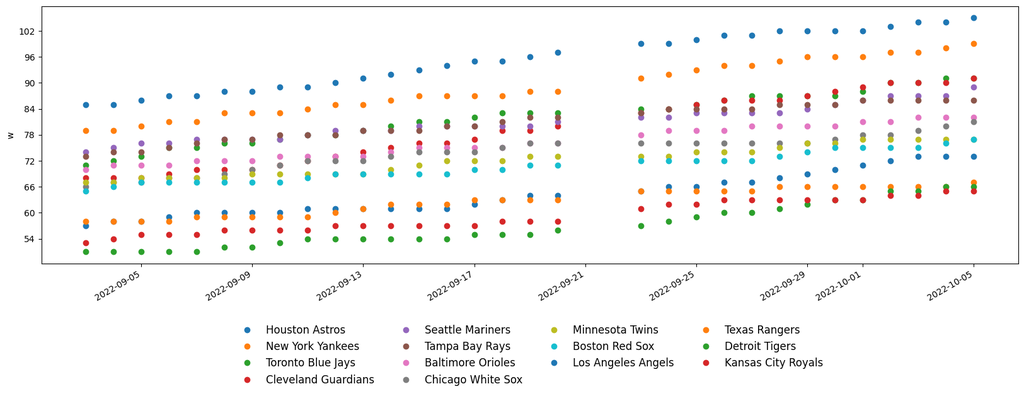

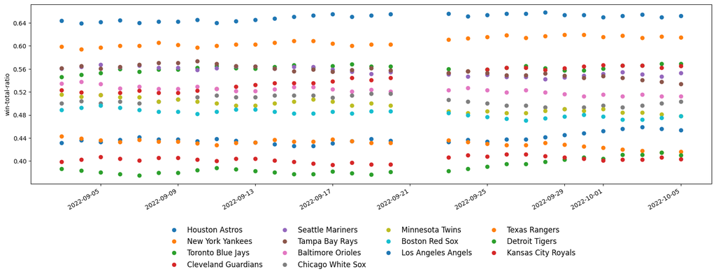

## Batting summary

Time series evolution of home runs and obp:

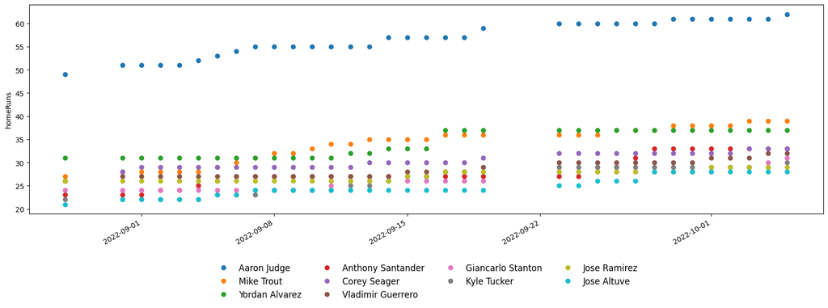

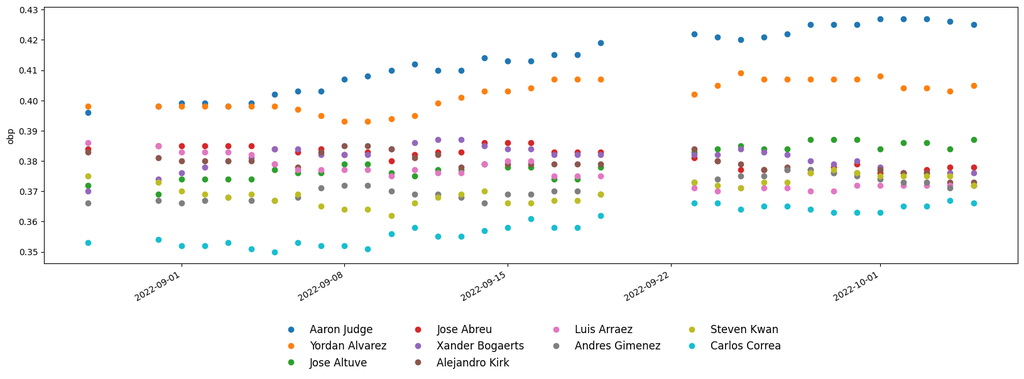

### Runs batted in (RBI)

Who is really 🔥💥 ?

|  | playername | rbiperplateAppearance |
| --- | --- | --- |
| 592450 | Aaron Judge | 0.188220 |
| 608070 | Jose Ramirez | 0.182350 |
| 643376 | Danny Jansen | 0.178420 |
| 663656 | Kyle Tucker | 0.175990 |
| 519317 | Giancarlo Stanton | 0.172570 |
| 670541 | Yordan Alvarez | 0.172040 |
| 671221 | Drew Waters | 0.171430 |
| 650391 | Eloy Jimenez | 0.165140 |
| 660650 | Dermis Garcia | 0.163930 |
| 521692 | Salvador Perez | 0.160680 |

And who is not 🧊🐢 ?

|  | playername | rbiperplateAppearance |
| --- | --- | --- |
| 681146 | Jonah Bride | 0.032090 |
| 668731 | Akil Baddoo | 0.040910 |
| 670032 | Nicky Lopez | 0.041670 |
| 669352 | Bubba Thompson | 0.044940 |
| 664702 | Myles Straw | 0.050680 |
| 669397 | Nick Allen | 0.055730 |
| 544725 | Leury Garcia | 0.063490 |
| 669701 | H. Smith | 0.064260 |
| 665482 | Gilberto Celestino | 0.064330 |
| 622110 | Matt Duffy | 0.065840 |

Who to watch? Biggest improvement from last week:

|  | playername | rbiperplateAppearancedifference |
| --- | --- | --- |
| 669127 | Shea Langeliers | 0.023770 |
| 571745 | Mitch Haniger | 0.015990 |
| 656811 | Ryan O'Hearn | 0.015450 |
| 643376 | Danny Jansen | 0.013240 |
| 671277 | Luis Garcia | 0.010820 |
| 647351 | Abraham Toro | 0.010210 |
| 462101 | Elvis Andrus | 0.009510 |
| 503556 | Marwin Gonzalez | 0.009300 |
| 666915 | Bobby Dalbec | 0.007050 |
| 622682 | Victor Reyes | 0.006730 |

### Homeruns (HRs)

Who is really 🔥💥 ?

|  | playername | homeRunsperplateAppearance |
| --- | --- | --- |
| 592450 | Aaron Judge | 0.089080 |
| 545361 | Mike Trout | 0.078790 |
| 519317 | Giancarlo Stanton | 0.068580 |
| 670541 | Yordan Alvarez | 0.066310 |
| 663728 | Cal Raleigh | 0.065060 |
| 643376 | Danny Jansen | 0.062240 |
| 519203 | Anthony Rizzo | 0.058820 |
| 670623 | Isaac Paredes | 0.053050 |
| 467793 | Carlos Santana | 0.051720 |
| 623993 | Anthony Santander | 0.051640 |

And who is not 🧊🐢 ?

|  | playername | homeRunsperplateAppearance |
| --- | --- | --- |
| 444482 | David Peralta | 0.000000 |
| 670032 | Nicky Lopez | 0.000000 |
| 543877 | Christian Vazquez | 0.000000 |
| 664702 | Myles Straw | 0.000000 |
| 624428 | Adam Frazier | 0.004980 |
| 681146 | Jonah Bride | 0.005350 |
| 669352 | Bubba Thompson | 0.005620 |
| 665482 | Gilberto Celestino | 0.005850 |
| 676694 | Jake Meyers | 0.006370 |
| 656811 | Ryan O'Hearn | 0.006900 |

Who to watch? Biggest improvement from last week:

|  | playername | homeRunsperplateAppearancedifference |
| --- | --- | --- |
| 669127 | Shea Langeliers | 0.015280 |
| 462101 | Elvis Andrus | 0.009930 |
| 571745 | Mitch Haniger | 0.008890 |
| 665828 | Oswaldo Cabrera | 0.007560 |
| 543309 | Kyle Higashioka | 0.005730 |
| 622682 | Victor Reyes | 0.005670 |
| 672284 | Jarred Kelenic | 0.004840 |
| 669087 | Sam Huff | 0.004660 |
| 519317 | Giancarlo Stanton | 0.004360 |
| 455139 | Robinson Chirinos | 0.004220 |

### Strike-outs

Remember, unlike runs batted in and home-runs, strike-outs are bad! You cannot score runs if you do not put the ball in play!

Who is really 🔥💥 ?

|  | playername | strikeOutsperplateAppearance |
| --- | --- | --- |
| 664058 | David Fletcher | 0.071429 |
| 650333 | Luis Arraez | 0.071667 |
| 680757 | Steven Kwan | 0.093207 |
| 677551 | Wander Franco | 0.095930 |
| 672386 | Alejandro Kirk | 0.105751 |
| 650490 | Yandy Diaz | 0.107527 |
| 686469 | Vinnie Pasquantino | 0.115646 |
| 608324 | Alex Bregman | 0.118098 |
| 608070 | Jose Ramirez | 0.120588 |
| 624428 | Adam Frazier | 0.121262 |

And who is not 🧊🐢 ?

|  | playername | strikeOutsperplateAppearance |
| --- | --- | --- |
| 660650 | Dermis Garcia | 0.426230 |
| 666176 | Jo Adell | 0.379433 |
| 663853 | Romy Gonzalez | 0.361905 |
| 669127 | Shea Langeliers | 0.348684 |
| 671221 | Drew Waters | 0.342857 |
| 672284 | Jarred Kelenic | 0.342697 |
| 642350 | Jose Siri | 0.338983 |
| 676694 | Jake Meyers | 0.337580 |
| 666915 | Bobby Dalbec | 0.335227 |
| 660271 | Shohei Ohtani | 0.321752 |

Who to watch? Biggest improvement from last week:

|  | playername | strikeOutsperplateAppearancedifference |
| --- | --- | --- |
| 669127 | Shea Langeliers | -0.038410 |
| 681987 | Nate Eaton | -0.036360 |
| 668731 | Akil Baddoo | -0.025920 |
| 622110 | Matt Duffy | -0.011690 |
| 686681 | Michael Massey | -0.011680 |
| 660650 | Dermis Garcia | -0.010660 |
| 669397 | Nick Allen | -0.010610 |
| 641820 | Trey Mancini | -0.008420 |
| 665482 | Gilberto Celestino | -0.008310 |
| 606992 | Eric Haase | -0.008040 |